# TOBIT, HECKIT

Данная глава посвящена моделям с цензурированными выборками. В таких выборках часть значений целевой переменной будет дискретной переменной, а часть - непрерывной. Простой пример, который указывается в некоторых учебниках, это исследование расходов семей на автомобили. Каждая семья может либо потратить какую-то сумму на автомобиль, либо, если она не может позволить себе автомобиль, то значение расходов будет равно нулю. Соответственно, переменная демонстрирует либо факт неучастия в покупке автомобиля, либо степень участия в виде суммы. Оценивается в данном случае обычная регрессионная модель, но с функцией правдоподобия следующего вида:

$$\begin{equation}
L=\prod_{y_{t}=0}\left(1-\Phi\left(\frac{\boldsymbol{x}_{t}^{\prime} \boldsymbol{\beta}}{\sigma}\right)\right) \prod_{y_{t}>0} \frac{1}{\sqrt{2 \pi} \sigma} \exp \left(-\frac{1}{2 \sigma^{2}}\left(y_{t}-\boldsymbol{x}_{t}^{\prime} \boldsymbol{\beta}\right)^{2}\right)
\end{equation}$$

```r
library(tidyverse) # Обработка данных
library(AER) # tobit-модель
library(sampleSelection) # heckit - модель
library(ltm) #margins
library(rio)
library(skimr)
```

Для начала подгрузим данные и визуализируем их. Этот датасет результаты тестирования двухсот школьников по шкале от 200 до 800 (apt), а также их успеваемость по чтению и математике (read и math соответственно). Построим гистограмму, наложив поверх неё функцию плотности нормального распределения.

```r
data = import('tobit.csv')
```

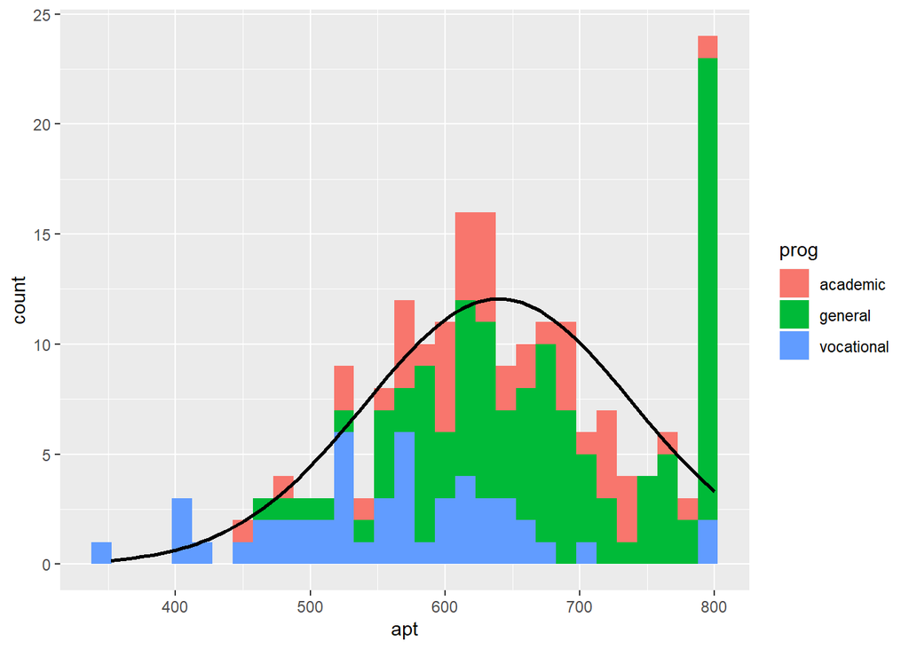

```r
# Функция, генерирующая функцию плотности нормального распределения в соответствии с распределением вектора входных данных
f <- function(x, var, bw = 15) {
  dnorm(x, mean = mean(var), sd(var)) * length(var)  * bw
}


p <- ggplot(data, aes(x = apt, fill=prog))
p + stat_bin(binwidth=15) +
  stat_function(fun = f, size = 1,
    args = list(var = data$apt))
```

Как можем видеть, нашлось довольно много школьников, которые написали тест на высший балл. В связи с этим распределение даллеко от нормального из-за ограничений баллов теста. Вид выборки также довольно специфичен при взгляде на диаграмму рассеяния. Довольно различимая линейная зависимость как бы сплюснута сверху.

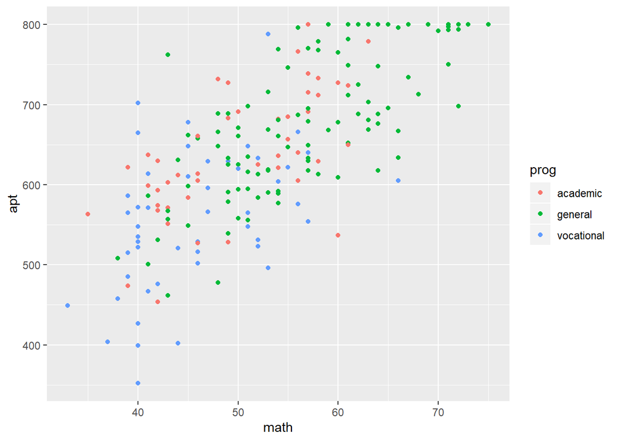

```r
g <- ggplot(data, aes(math, apt, col = prog))
g +geom_point()
```

Оценим Тобит-модель:

```r
model_tobit = tobit(apt ~ math + read, data = data, right = 800)
summary(model_tobit)
```

[output not shown]

[output not shown]

Модель Тобина имеет ряд ограничений. Основное из них – это зависимость вероятности участия и интенсивности участия определяется одним и тем же набором переменных. Для преодоления этих ограничений была предложена модель Хекмана. В ней принятие решения “участвовать - не участвовать” и определение степени участия могут зависеть от разных переменных.

Загрузим другие данные во славу разнообразия.

```r
data = import('data_alcohol&tobacco.dta')
summary(data)
```

```
     obs                 age           bluecol            lnx
 Length:2724        Min.   :0.000   Min.   :0.0000   Min.   :11.76
 Class :character   1st Qu.:1.000   1st Qu.:0.0000   1st Qu.:13.41
 Mode  :character   Median :2.000   Median :0.0000   Median :13.76
                    Mean   :2.408   Mean   :0.1468   Mean   :13.73
                    3rd Qu.:4.000   3rd Qu.:0.0000   3rd Qu.:14.06
                    Max.   :4.000   Max.   :1.0000   Max.   :15.33
    flanders         nadults        ninfants           nkids
 Min.   :0.0000   Min.   :1.00   Min.   :0.00000   Min.   :0.0000
 1st Qu.:0.0000   1st Qu.:1.00   1st Qu.:0.00000   1st Qu.:0.0000
 Median :0.0000   Median :2.00   Median :0.00000   Median :0.0000
 Mean   :0.4519   Mean   :1.97   Mean   :0.04479   Mean   :0.5646
 3rd Qu.:1.0000   3rd Qu.:2.00   3rd Qu.:0.00000   3rd Qu.:1.0000
 Max.   :1.0000   Max.   :7.00   Max.   :2.00000   Max.   :5.0000
     resid                shalc              shtob
 Min.   :-0.9797682   Min.   :0.000000   Min.   :0.00000
 1st Qu.: 0.0626030   1st Qu.:0.002906   1st Qu.:0.00000
 Median : 0.1223031   Median :0.010898   Median :0.00000
 Mean   : 0.0001171   Mean   :0.017828   Mean   :0.01224
 3rd Qu.: 0.1854353   3rd Qu.:0.024244   3rd Qu.:0.01381
 Max.   : 0.5795787   Max.   :0.211124   Max.   :0.19276
    walloon          whitecol      shalc_tobit             alc
 Min.   :0.0000   Min.   :0.000   Min.   :-0.005627   Min.   :0.0000
 1st Qu.:0.0000   1st Qu.:0.000   1st Qu.: 0.010925   1st Qu.:1.0000
 Median :0.0000   Median :0.000   Median : 0.015169   Median :1.0000
 Mean   :0.3814   Mean   :0.333   Mean   : 0.015198   Mean   :0.8289
 3rd Qu.:1.0000   3rd Qu.:1.000   3rd Qu.: 0.019735   3rd Qu.:1.0000
 Max.   :1.0000   Max.   :1.000   Max.   : 0.032814   Max.   :1.0000
      tob
 Min.   :0.0000
 1st Qu.:0.0000
 Median :0.0000
 Mean   :0.3803
 3rd Qu.:1.0000
 Max.   :1.0000
```

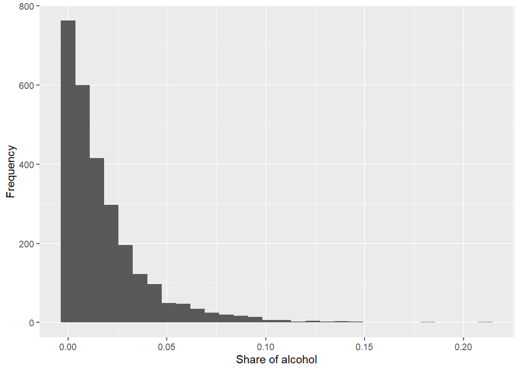

```r
p <- ggplot(data, aes(x = shalc)) + geom_histogram() + ylab("Frequency") + xlab("Share of alcohol")


plot(p)
```

```r
heck1 = heckit(alc ~ age + nadults + nkids + lnx + walloon, shalc ~  age + nadults + nkids + lnx + walloon, data = data, method = 'ml')
summary(heck1)
```

```
--------------------------------------------
Tobit 2 model (sample selection model)
Maximum Likelihood estimation
Newton-Raphson maximisation, 5 iterations
Return code 2: successive function values within tolerance limit
Log-Likelihood: 4311.465
2724 observations (466 censored and 2258 observed)
14 free parameters (df = 2710)
Probit selection equation:
             Estimate Std. Error t value Pr(>|t|)
(Intercept) -11.12847    0.99823 -11.148  < 2e-16 ***
age           0.06449    0.02333   2.765  0.00574 **
nadults      -0.08657    0.04198  -2.062  0.03927 *
nkids        -0.08477    0.03621  -2.341  0.01929 *
lnx           0.88399    0.07585  11.654  < 2e-16 ***
walloon       0.19751    0.06229   3.171  0.00154 **
Outcome equation:
              Estimate Std. Error t value Pr(>|t|)
(Intercept)  0.0413302  0.0205897   2.007 0.044815 *
age          0.0022075  0.0003854   5.727 1.13e-08 ***
nadults     -0.0017463  0.0006455  -2.705 0.006865 **
nkids       -0.0021381  0.0005640  -3.791 0.000153 ***
lnx         -0.0015570  0.0014823  -1.050 0.293642
walloon      0.0025647  0.0009575   2.679 0.007437 **
   Error terms:
        Estimate Std. Error t value Pr(>|t|)
sigma  0.0214606  0.0003194  67.187   <2e-16 ***
rho   -0.0062437  0.1345571  -0.046    0.963
---
Signif. codes:  0 '***' 0.001 '**' 0.01 '*' 0.05 '.' 0.1 ' ' 1
--------------------------------------------
```

```r
heck2 = heckit2fit(alc ~ age + nadults + nkids + lnx + walloon, shalc ~  age + nadults + nkids + lnx + walloon, data = data)
summary(heck2)
```

```
--------------------------------------------
Tobit 2 model (sample selection model)
2-step Heckman / heckit estimation
2724 observations (466 censored and 2258 observed)
15 free parameters (df = 2710)
Probit selection equation:
             Estimate Std. Error t value Pr(>|t|)
(Intercept) -11.12810    0.99819 -11.148  < 2e-16 ***
age           0.06448    0.02332   2.765  0.00574 **
nadults      -0.08653    0.04196  -2.062  0.03930 *
nkids        -0.08475    0.03620  -2.341  0.01931 *
lnx           0.88396    0.07585  11.654  < 2e-16 ***
walloon       0.19748    0.06228   3.171  0.00154 **
Outcome equation:
              Estimate Std. Error t value Pr(>|t|)
(Intercept)  0.0584579  0.0763935   0.765 0.444207
age          0.0021170  0.0005482   3.862 0.000115 ***
nadults     -0.0016402  0.0007920  -2.071 0.038456 *
nkids       -0.0020387  0.0007089  -2.876 0.004062 **
lnx         -0.0027209  0.0052148  -0.522 0.601873
walloon      0.0023175  0.0014319   1.619 0.105666
Multiple R-Squared:0.0534,  Adjusted R-Squared:0.0509
   Error terms:
               Estimate Std. Error t value Pr(>|t|)
invMillsRatio -0.003805   0.016022  -0.237    0.812
sigma          0.021579         NA      NA       NA
rho           -0.176330         NA      NA       NA
--------------------------------------------
```

Теперь то же самое в STATA.

```stata
clear
use tobit
summarize
```

```
    Variable |       Obs        Mean
> Std. Dev.       Min        Max
-------------+--------------------------
> ------------------------------
          v1 |       200        99.5
> 57.87918          0        199
    unnamed0 |       200        99.5
> 57.87918          0        199
          id |       200       100.5
> 57.87918          1        200
        read |       200       52.23
> 10.25294         28         76
        math |       200      52.645
> 9.368448         33         75
-------------+--------------------------
> ------------------------------
        prog |         0
         apt |       200     640.035
> 99.21903        352        800
         top |       200        .915
> .2795815          0          1
```

```stata
egen prog_2 = group(prog)
tobit apt read math i.prog_2, ul
```

```
Tobit regression
>           Number of obs
>                           =        200

>           LR chi2(4)
>                           =     188.97

>           Prob > chi2
>                           =     0.0000
Log likelihood = -1041.0629
>           Pseudo R2
>                           =     0.0832

----------------------------------------
> --------------------------------------
         apt |      Coef.   Std. Err.
>    t
>         P>|t|
>                   [95% Con
>                           f. Interval]
-------------+--------------------------
> --------------------------------------
        read |   2.697939    .618798
>  4.36
>         0.000
>                   1.477582
>                               3.918296
        math |   5.914485   .7098063
>  8.33
>         0.000
>                   4.514647
>                               7.314323
      prog_2 |
          2  |  -12.71476   12.40629
> -1.02
>         0.307
>                  -37.18173
>                                11.7522
          3  |   -46.1439   13.72401
> -3.36
>         0.001
>                   -73.2096
>                              -19.07821
       _cons |    209.566   32.77154
>  6.39
>         0.000
>                   144.9359
>                               274.1961
-------------+--------------------------
> --------------------------------------
      /sigma |   65.67672   3.481272
>                   58.81116
>                               72.54228
----------------------------------------
> --------------------------------------
  Obs. summary:          0  left-censore
> d observations
                       183     uncensore
> d observations
                        17 right-censore
> d observations at apt>=800
```

```stata
clear all
use data_alcohol&tobacco
heckman shalc age nadults nkids lnx walloon, select(alc = age nadults nkids lnx walloon)
```

```
Iteration 0:   log likelihood =  4309.53
> 07
Iteration 1:   log likelihood =  4311.39
> 49
Iteration 2:   log likelihood =  4311.46
> 38
Iteration 3:   log likelihood =  4311.46
> 49
Iteration 4:   log likelihood =  4311.46
> 49

Heckman selection model
>         Number of obs      =      2724
(regression model with sample selection)
>         Censored obs       =       466

>         Uncensored obs     =      2258


>         Wald chi2(5)       =    126.74
Log likelihood =  4311.465
>         Prob > chi2        =    0.0000

----------------------------------------
> --------------------------------------
             |      Coef.   Std. Err.
>    z
>         P>|z|
>                   [95% Con
>                           f. Interval]
-------------+--------------------------
> --------------------------------------
shalc        |
         age |   .0022075   .0003854
>  5.73
>         0.000
>                   .0014521
>                                .002963
     nadults |  -.0017463   .0006455
> -2.71
```

[output cut: 68 more lines]

```
-------------+--------------------------
> --------------------------------------
         rho |  -.0062433   .1345579
>                  -.2636083
>                               .2519516
       sigma |   .0214606   .0003194
>                   .0208436
>                               .0220958
      lambda |   -.000134   .0028877
>                  -.0057938
>                               .0055259
----------------------------------------
> --------------------------------------
LR test of indep. eqns. (rho = 0):   chi
> 2(1) =     0.00   Prob > chi2 = 0.9640
```

```stata
heckman shalc age nadults nkids lnx walloon, select(alc = age nadults nkids lnx walloon) twostep
```

```
> lloon, select(alc = age nadults nkids
> lnx walloon) twostep

Heckman selection model -- two-step esti
> mates   Number of obs      =      2724
(regression model with sample selection)
>         Censored obs       =       466

>         Uncensored obs     =      2258


>         Wald chi2(5)       =    125.15

>         Prob > chi2        =    0.0000

----------------------------------------
> --------------------------------------
             |      Coef.   Std. Err.
>    z
>         P>|z|
>                   [95% Con
>                           f. Interval]
-------------+--------------------------
> --------------------------------------
shalc        |
         age |    .002117   .0005482
>  3.86
>         0.000
>                   .0010426
>                               .0031915
     nadults |  -.0016402    .000792
> -2.07
>         0.038
>                  -.0031925
>                              -.0000879
       nkids |  -.0020387   .0007089
> -2.88
>         0.004
>                  -.0034282
>                              -.0006492
```

[output cut: 47 more lines]

```
>                              -9.171695
-------------+--------------------------
> --------------------------------------
mills        |
      lambda |   -.003805    .016022
> -0.24
>         0.812
>                  -.0352075
>                               .0275975
-------------+--------------------------
> --------------------------------------
         rho |   -0.17633
       sigma |  .02157888
----------------------------------------
> --------------------------------------
```

Частично воспроизведём в Python. Для начала подгрузим библиотеки

```python
import pandas as pd # Чтение и обработка данных
import tobin as tb # Модель Тобина
```

[output not shown]

Прочтём данные. Для цензурирования создадим новую переменную “cens”, которая равна единице, если студент получил высший балл. Также выделим зависимую переменную и оставим в датасете только зависимые переменные.

```python
data = pd.read_csv('tobit.csv', index_col = 'id')
cens = (data.apt == 800).astype('int')
Y = data.apt
data = data.drop(columns = ['apt', 'prog'])
```

Оценим модель

```r
tobit = tb.TobitModel()
```

[output not shown]

```r
tobit_fitted = tobit.fit(data, Y, cens)
```

[output not shown]

Для модели Хекмана не было найдено хорошего и завершённого пакета на Python. Лучше воспользоваться другими инструментами.